# DataSci 271: Exercise 1

May 08, 2016

The file birthweight_w271.Rdatabirthweight_w271.Rdata contains data from the 1988 National Health Interview Survey 1988 National Health Interview Survey, which is modified by the instructor. This survey is conducted by the U.S. Census Bureau and has collected data on individual health metrics since 1957. Like all surveys, a full analysis would require advanced techniques such as those provided by the R survey package. For this homework, however, you are to treat the data as a true random sample. You will use this dataset to practice interpreting OLS coefficients.

## Question 1: Examine the basic structure of the data

Load the birthweight dataset. * Examine the basic structure of the data set. RR functions such as desc, str, summarydesc, str, summary may be useful. * Describe the number of variables and observations in the data. * Examine if there are any missing values in each of the variables.

```r
library(data.table)
library(dplyr)
library(stargazer)
library(Hmisc)
rm(list = ls())
load('birthweight_w271.rdata')
summary(data)
```

```
##      faminc          cigtax         cigprice         bwght
##  Min.   : 0.50   Min.   : 2.00   Min.   :103.8   Min.   :  0.0
##  1st Qu.:14.50   1st Qu.:15.00   1st Qu.:122.8   1st Qu.:106.0
##  Median :27.50   Median :20.00   Median :130.8   Median :119.0
##  Mean   :29.03   Mean   :19.55   Mean   :130.6   Mean   :117.9
##  3rd Qu.:37.50   3rd Qu.:26.00   3rd Qu.:137.0   3rd Qu.:132.0
##  Max.   :65.00   Max.   :38.00   Max.   :152.5   Max.   :271.0
##
##     fatheduc        motheduc         parity           male
##  Min.   : 1.00   Min.   : 2.00   Min.   :1.000   Min.   :0.0000
##  1st Qu.:12.00   1st Qu.:12.00   1st Qu.:1.000   1st Qu.:0.0000
##  Median :12.00   Median :12.00   Median :1.000   Median :1.0000
##  Mean   :13.19   Mean   :12.94   Mean   :1.633   Mean   :0.5209
##  3rd Qu.:16.00   3rd Qu.:14.00   3rd Qu.:2.000   3rd Qu.:1.0000
##  Max.   :18.00   Max.   :18.00   Max.   :6.000   Max.   :1.0000
##  NA's   :196     NA's   :1
##      white             cigs            lbwght         bwghtlbs
##  Min.   :0.0000   Min.   : 0.000   Min.   :0.000   Min.   : 0.000
##  1st Qu.:1.0000   1st Qu.: 0.000   1st Qu.:4.663   1st Qu.: 6.625
##  Median :1.0000   Median : 0.000   Median :4.779   Median : 7.438
##  Mean   :0.7846   Mean   : 2.087   Mean   :4.726   Mean   : 7.366
##  3rd Qu.:1.0000   3rd Qu.: 0.000   3rd Qu.:4.883   3rd Qu.: 8.250
##  Max.   :1.0000   Max.   :50.000   Max.   :5.602   Max.   :16.938
##
##      packs           lfaminc
##  Min.   :0.0000   Min.   :-0.6931
##  1st Qu.:0.0000   1st Qu.: 2.6741
##  Median :0.0000   Median : 3.3142
##  Mean   :0.1044   Mean   : 3.0713
##  3rd Qu.:0.0000   3rd Qu.: 3.6243
##  Max.   :2.5000   Max.   : 4.1744
##
```

```r
describe(data)
```

```
## data
##
##  14  Variables      1388  Observations
## ---------------------------------------------------------------------------
## faminc
##       n missing  unique    Info    Mean     .05     .10     .25     .50
##    1388       0      27    0.99   29.03     3.5     6.5    14.5    27.5
##     .75     .90     .95
##    37.5    65.0    65.0
##
## lowest :  0.5  1.5  2.5  3.5  4.5, highest: 32.5 37.5 42.5 47.5 65.0
## ---------------------------------------------------------------------------
## cigtax
##       n missing  unique    Info    Mean     .05     .10     .25     .50
##    1388       0      28    0.99   19.55       3      10      15      20
##     .75     .90     .95
##      26      27      31
##
## lowest :  2.0  2.5  3.0  7.0  8.0, highest: 30.0 31.0 33.0 34.0 38.0
## ---------------------------------------------------------------------------
## cigprice
##       n missing  unique    Info    Mean     .05     .10     .25     .50
##    1388       0      46       1   130.6   109.4   120.2   122.8   130.8
##     .75     .90     .95
##   137.0   142.0   148.6
##
## lowest : 103.8 107.6 109.4 111.9 118.6
## highest: 145.6 148.6 149.1 150.6 152.5
## ---------------------------------------------------------------------------
## bwght
##       n missing  unique    Info    Mean     .05     .10     .25     .50
##    1388       0     117       1   117.9      83      93     106     119
##     .75     .90     .95
##     132     143     149
##
## lowest :   0  23  30  35  38, highest: 170 172 176 192 271
## ---------------------------------------------------------------------------
## fatheduc
##       n missing  unique    Info    Mean     .05     .10     .25     .50
##    1192     196      18    0.94   13.19       9      10      12      12
```

[output cut: 73 more lines]

```
## 0.400000005960464 (5, 0%)
## 0.449999988079071 (1, 0%), 0.5 (55, 4%)
## 0.600000023841858 (5, 0%), 0.75 (19, 1%)
## 1 (62, 4%), 1.5 (5, 0%), 2 (6, 0%), 2.29999995231628 (1, 0%)
## 2.5 (1, 0%)
## ---------------------------------------------------------------------------
## lfaminc
##       n missing  unique    Info    Mean     .05     .10     .25     .50
##    1388       0      27    0.99   3.071   1.253   1.872   2.674   3.314
##     .75     .90     .95
##   3.624   4.174   4.174
##
## lowest : -0.6931  0.4055  0.9163  1.2528  1.5041
## highest:  3.4812  3.6243  3.7495  3.8607  4.1744
## ---------------------------------------------------------------------------
```

## Question 2: Exploratory Data Analysis (EDA)

As we mentioned in the live session, it is important to start with a question (or a hypothesis) when conducting regression modeling. In this execrise, we are in the question: “Do mothers who smoke have babies with lower birth weight?”

The dependent variable of interested is bwght, representing birthweight in ounces. Examine this variable using both tabulated and graphical summaries.

```r
summary(data$bwght)
```

```
##    Min. 1st Qu.  Median    Mean 3rd Qu.    Max.
##     0.0   106.0   119.0   117.9   132.0   271.0
```

```r
quantile(data$bwght, probs=c(0.01, 0.05, .1, .25, .5, .75, .9, .95, .99))
```

```
##     1%     5%    10%    25%    50%    75%    90%    95%    99%
##  42.35  83.00  93.00 106.00 119.00 132.00 143.00 149.00 160.13
```

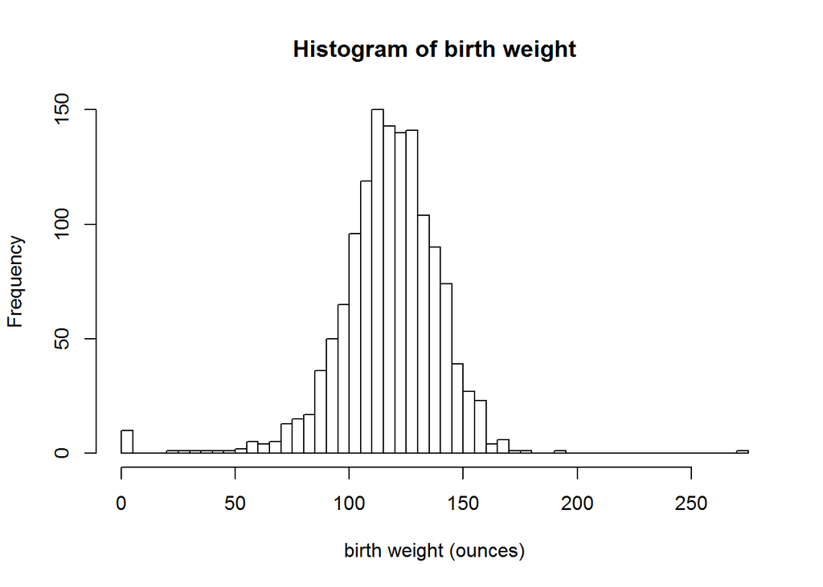

```r
hist(data$bwght, breaks=40, main="Histogram of birth weight", xlab="birth weight (ounces)")
```

```r
table(data$bwght)
```

```
##
##   0  23  30  35  38  43  50  52  54  56  58  60  61  64  68  69  70  71
##  10   1   1   1   1   1   1   1   1   1   2   2   1   3   3   1   1   2
##  72  73  74  75  76  77  78  79  80  81  82  83  84  85  86  87  88  89
##   2   2   4   3   3   1   2   6   3   3   4   5   3   2   7   9   5   6
##  90  91  92  93  94  95  96  97  98  99 100 101 102 103 104 105 106 107
##   9  13  10  13   9   5  12  15  17   9  12  18  19  16  29  14  26  22
## 108 109 110 111 112 113 114 115 116 117 118 119 120 121 122 123 124 125
##  25  24  22  18  36  26  34  36  25  26  22  29  41  21  30  35  29  25
## 126 127 128 129 130 131 132 133 134 135 136 137 138 139 140 141 142 143
##  27  24  41  22  27  19  20  21  28  16  29  16  14  21  10  19  15  13
## 144 145 146 147 148 149 150 151 152 153 154 155 156 157 158 159 160 161
##  17  10  12   9   5  10   3   6  10   4   3   4   6   2   3   6   6   3
## 164 166 167 169 170 172 176 192 271
##   1   3   1   1   1   1   1   1   1
```

The key explanatory variable of interest is cigs, which represents number of cigarettes smoked each day by the mother while pregnant. Conduct the same EDA analysis as that of the dependent variable.